# Anomalías térmicas en Costa Rica — VIIRS NOAA-20

Detecciones del sensor VIIRS a bordo de NOAA-20 (VIIRS_NOAA20_SP de NASA FIRMS)

Autor/a

Organización Incendios Forestales

Fecha de publicación

17 de noviembre de 2026

## Introducción

Este reporte presenta las anomalías térmicas (detecciones de fuego activo) registradas por el sensor **VIIRS** a bordo del satélite **NOAA-20** en el territorio continental de **Costa Rica**. Es el tercero de una serie de reportes análogos, junto con los de MODIS (Terra y Aqua, desde 2001) y VIIRS en Suomi-NPP (desde 2012): misma metodología, mismos productos, distinta plataforma de observación. El ámbito es **continental** (sin la Isla del Coco) y el límite nacional es la unión de las siete provincias de la cartografía oficial 1:5000 del IGN; los detalles están en el reporte MODIS.

NOAA-20 lleva **el mismo instrumento** que Suomi-NPP —VIIRS, con píxel de 375 m en las bandas de imagen— pero vuela media órbita por detrás, de modo que pasa sobre el país unos cincuenta minutos después. No observa los mismos fuegos en los mismos instantes, sino que **añade oportunidades de observación**: un fuego encendido entre ambos pasos aparece en uno y no en el otro. Por eso sus detecciones se publican como serie propia y no se suman a las de Suomi-NPP; sumarlas produciría un salto artificial en 2018, cuando NOAA-20 entra en operación, que reflejaría el número de satélites en órbita y no el régimen de fuego.

El período analizado va del **01/04/2018** al **15/11/2026**, con un total de **41 131** detecciones dentro del país.

### Una advertencia sobre el área quemada

A diferencia de MODIS y Suomi-NPP, **NOAA-20 no tiene producto de área quemada**: el equivalente que le correspondería (`VJ164A1`) no ha sido publicado. El único producto de área quemada de la familia VIIRS es **VNP64A1**, derivado de Suomi-NPP.

Este reporte lo usa de todas formas, recortado al período de NOAA-20 y **rotulado como «VNP64A1, S-NPP»** en cada figura, tabla y leyenda donde aparece. Es una decisión defendible porque el área quemada es una medición distinta de la de fuego activo —la superficie que quedó marcada, en píxeles de 500 m— y no detecciones de otro sensor mezcladas con las de este. Pero conviene tenerlo presente al leer: **las hectáreas de este reporte no provienen de NOAA-20**, y cuando se comparan las dos series de un mismo gráfico se están comparando dos plataformas.

## Mapa animado

Detecciones mensuales de anomalías térmicas; el color indica la potencia radiativa del fuego (FRP).

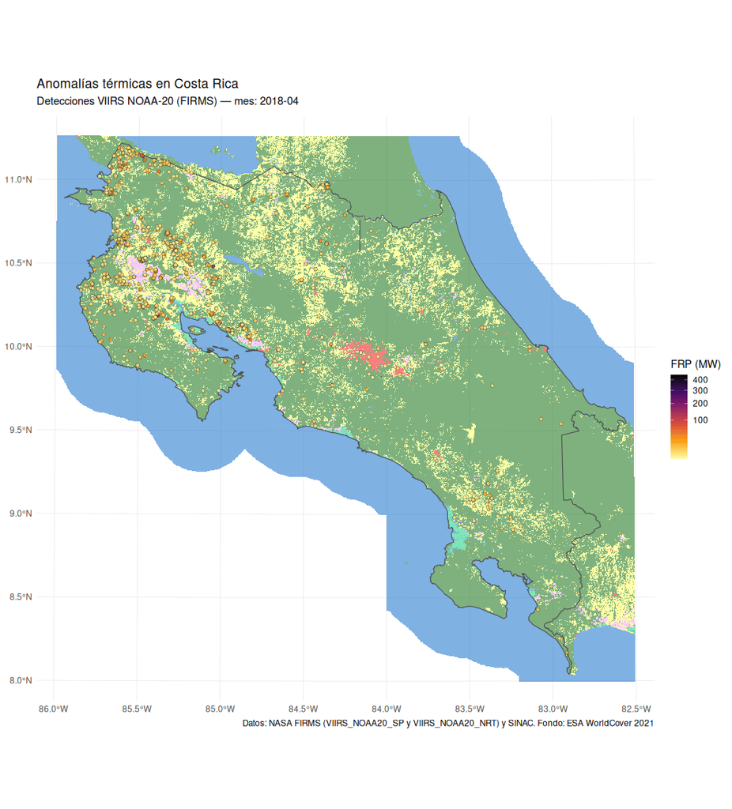

## Video resumen

Resumen mensual en formato de video: detecciones de fuego activo (VIIRS NOAA-20) con su estela de los meses recientes y píxeles de área quemada (VNP64A1, de Suomi-NPP), sobre el relieve del país teñido por la cobertura de la tierra (WorldCover 2021).

[video not shown]

El cartel estático resume las dos series mensuales del video.

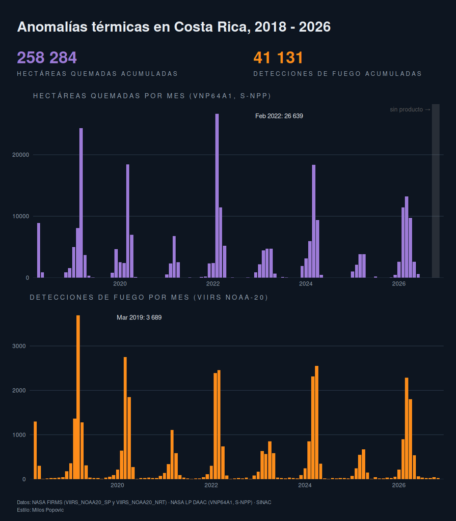

## Mapa interactivo

A escala nacional el registro completo suma demasiadas detecciones para mostrar cada una con su ficha, así que el mapa las divide en dos capas: los **últimos 24 meses** con el deslizador temporal y una ficha por detección, y el **registro completo** como una capa de puntos ligera (WebGL), apagada al inicio. El botón ⛶ abre el mapa en pantalla completa. Como en todos los productos VIIRS, la confianza de cada detección es categórica —baja, nominal o alta— y no un porcentaje como en MODIS. Desde el control de capas puede activarse también la temporada de fuego consolidada por celda (ver la sección Temporada de fuego).

[interactive chart not shown]

## Estadísticas

### Serie temporal mensual

Detecciones de fuego activo (arriba) y hectáreas quemadas (abajo), con el eje temporal compartido. Las dos series son complementarias y **no sumables**, y en este reporte provienen además de plataformas distintas.

[interactive chart not shown]

### Climatología mensual (estacionalidad)

Promedios por mes calendario de ambas magnitudes.

[interactive chart not shown]

### Resumen anual

| Año | Detecciones | Hectáreas quemadas | FRP promedio (MW) | FRP máximo (MW) |
| --- | --- | --- | --- | --- |
| 2018 | 1925 | 12272 | 7 | 168.54 |
| 2019 | 7265 | 46821 | 5.9 | 194.35 |
| 2020 | 5947 | 30401 | 6.5 | 230.71 |
| 2021 | 2502 | 14688 | 6.5 | 107.04 |
| 2022 | 6161 | 46500 | 6.1 | 201.3 |
| 2023 | 3049 | 18771 | 8.9 | 413.5 |
| 2024 | 6435 | 37221 | 7 | 179.45 |
| 2025 | 1894 | 11395 | 7.2 | 218.86 |
| 2026 | 5953 | 40215 | 6.5 | 449.33 |

Al comparar este registro con el de Suomi-NPP conviene recordar que ambos llevan el mismo instrumento: las diferencias entre las dos series reflejan sobre todo las horas de paso y los episodios que cada plataforma alcanzó a observar, no una diferencia de sensibilidad.

## Temporada de fuego

Esta sección aplica a la serie de NOAA-20 la misma suite de índices anuales que los reportes de MODIS y de Suomi-NPP, con las mismas definiciones, fracciones y umbrales y sin mezclar detecciones de plataformas distintas. La unidad es el **año de fuego**, del 1 de setiembre al 31 de agosto y nombrado por el año en que termina; solo cuentan las detecciones de **vegetación** (columna `type` de FIRMS igual a 0 o ausente). El sustento de cada índice está en el reporte MODIS y en el [README](https://github.com/incendios-forestales/anomalias-termicas-costarica#año-de-fuego-e-índices-anuales); aquí se resumen sus resultados para esta plataforma.

Lo particular de NOAA-20 es la brevedad del registro: el procesamiento estándar empieza el 1 de abril de 2018, así que el año de fuego 2018 es parcial y los años completos van de 2019 en adelante. Su lectura natural es el contraste con Suomi-NPP, el mismo instrumento cincuenta minutos antes: donde los dos coinciden, el resultado no depende de qué pasadas alcanzó a ver cada satélite.

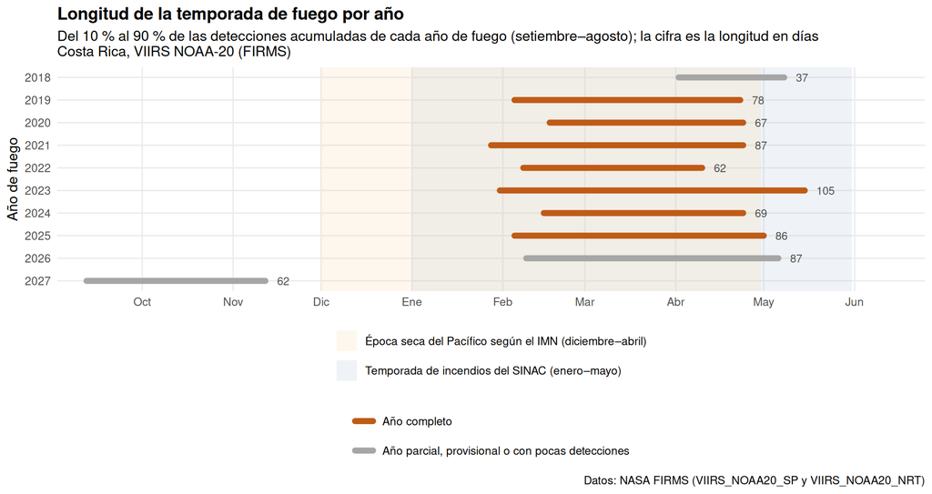

| Año de fuego | Detecciones | Inicio (10 %) | Fin (90 %) | Longitud (días) | Días de fuego | N50 (días) | C10 (%) | FRP mediana (MW) | FRP p95 (MW) | Días extremos | % en días extremos | Nota |
| --- | --- | --- | --- | --- | --- | --- | --- | --- | --- | --- | --- | --- |
| 2018 | 1618 | 2 de abril | 8 de mayo | 37 | 68 | 9 | 53.3 | 5 | 20.2 | 4 | 30.3 | año parcial |
| 2019 | 7283 | 5 de febrero | 23 de abril | 78 | 223 | 27 | 24.6 | 4.1 | 16.9 | 20 | 41.7 |  |
| 2020 | 5913 | 17 de febrero | 23 de abril | 67 | 210 | 27 | 22.5 | 4.5 | 18.4 | 19 | 38.7 |  |
| 2021 | 2454 | 28 de enero | 24 de abril | 87 | 208 | 25 | 29.6 | 4.6 | 18.1 | 0 | 0 |  |
| 2022 | 6178 | 8 de febrero | 10 de abril | 62 | 218 | 19 | 35.1 | 4 | 17.8 | 17 | 47.7 |  |
| 2023 | 3009 | 31 de enero | 15 de mayo | 105 | 216 | 34 | 20.9 | 4.6 | 25.1 | 0 | 0 |  |
| 2024 | 6474 | 15 de febrero | 23 de abril | 69 | 208 | 21 | 31 | 4.7 | 19.8 | 18 | 47.1 |  |
| 2025 | 1798 | 5 de febrero | 1 de mayo | 86 | 190 | 27 | 26 | 4.8 | 21.4 | 0 | 0 |  |
| 2026 | 5930 | 9 de febrero | 6 de mayo | 87 | 221 | 33 | 18.8 | 4.2 | 18.2 | 6 | 12.4 | provisional |
| 2027 | 95 | 12 de setiembre | 12 de noviembre | 62 | 36 | 9 | 53.7 | 3.6 | 15 | 0 | 0 | año parcial; provisional; &lt; 300 detecciones |

La tabla completa está disponible como CSV.

### Concentración diaria del fuego

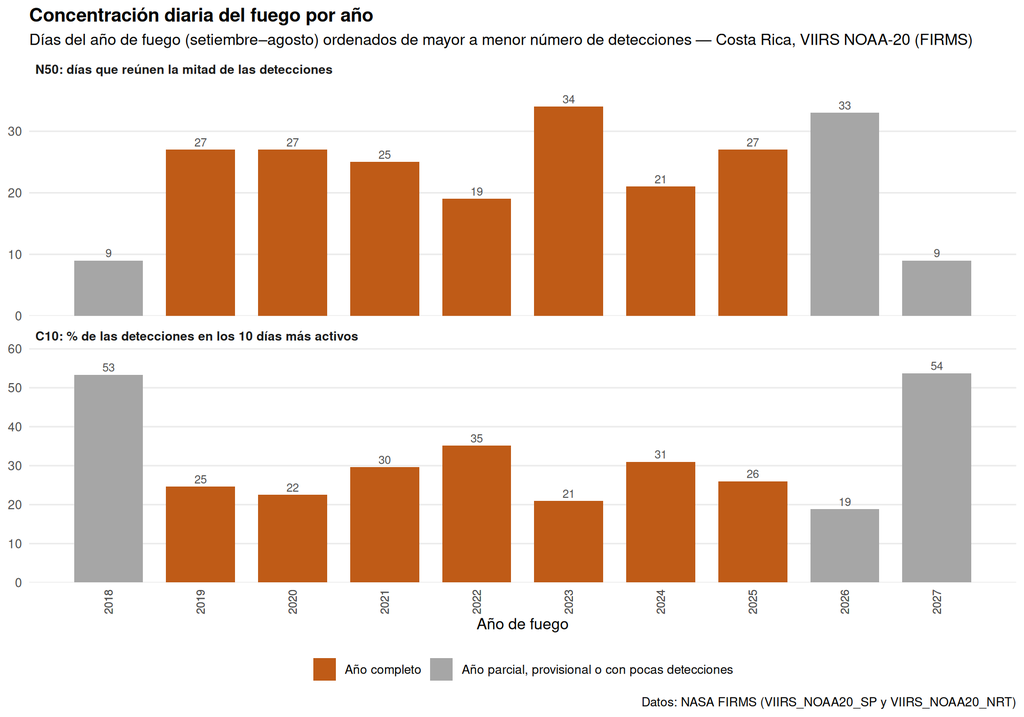

La mitad del fuego del año cabe en promedio en **26 días** (`N50`), entre los 19 de 2022 y los 34 de 2023, y los 10 días más activos concentran el **27 %** de las detecciones (`C10`), desde el 21 % de 2023 hasta el 35 % de 2022.

### Intensidad del fuego

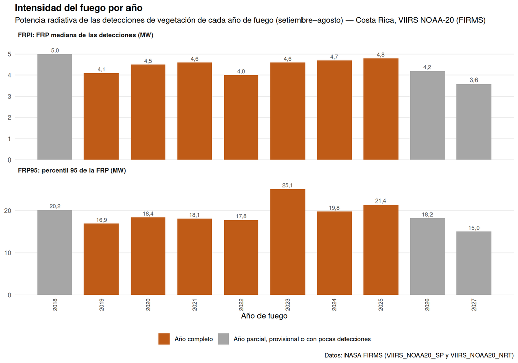

La FRP mediana de las detecciones de vegetación (`FRPI`) es de **4,5 MW** en los años completos, entre los 4,0 de 2022 y los 4,8 de 2025; el percentil 95 (`FRP95`) promedia 20 MW y alcanzó 25 MW en 2023. Son valores por píxel de 375 m y no se comparan con los de MODIS, solo entre años de esta serie y, con cautela, con los de Suomi-NPP. NOAA-20 es un solo satélite, así que no existe aquí el control de mezcla de satélites (`AQ`); el 24 % de las detecciones son nocturnas (`noc`).

### Días extremos

El umbral `P95` es el percentil 95 de las detecciones diarias en los días con fuego del **periodo base 2019–2025**, que coincide con los años completos del registro. Es un periodo corto: al quitar cualquiera de sus años el umbral se mueve varias detecciones, más que en Suomi-NPP o en MODIS, de modo que los días extremos de esta plataforma se leen como provisionales hasta que el registro crezca.

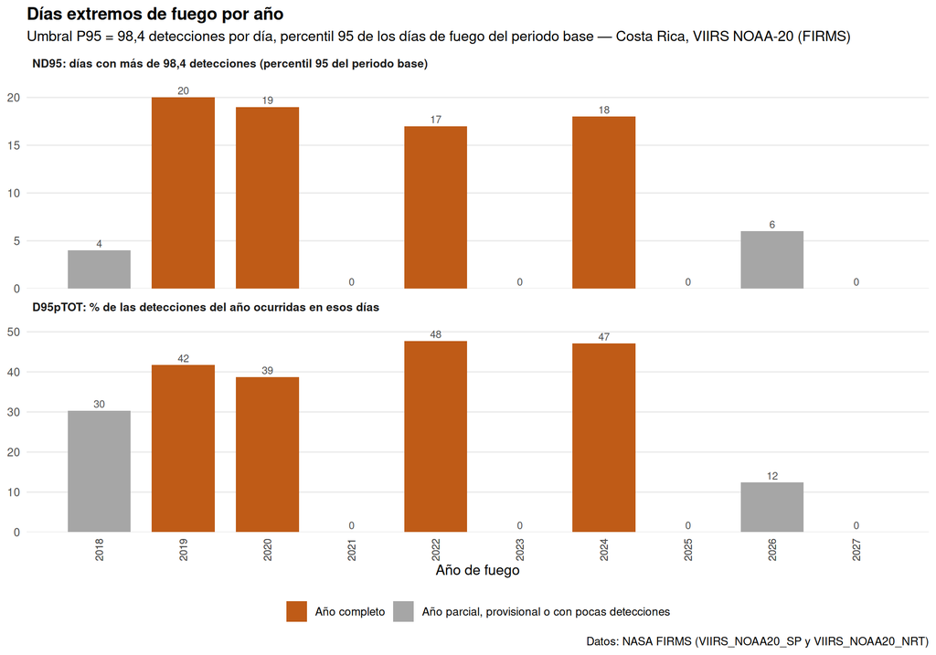

El umbral es de **98,4 detecciones por día**. En los 7 años completos hubo en promedio 10,6 días extremos por año, con un máximo de 20 en 2019; esos días concentran en promedio el 25 % de las detecciones del año, y hasta el 48 % en 2022. Hubo 3 años sin ningún día extremo (2021, 2023, 2025).

### Índices consolidados por celda

Sobre la grilla común de 0,1° se juntan las detecciones de vegetación de los años de fuego completos (2019–2025) y se calculan por celda `INI`, `FIN` y `LON` (temporada climatológica), `FUERA` (fracción fuera de diciembre a mayo; por encima del 25 %, celda sin estación definida, con trama) y `N50F` (concentración), con los mismos umbrales que en las otras plataformas: 30 detecciones para fechar la temporada y 100 para la concentración.

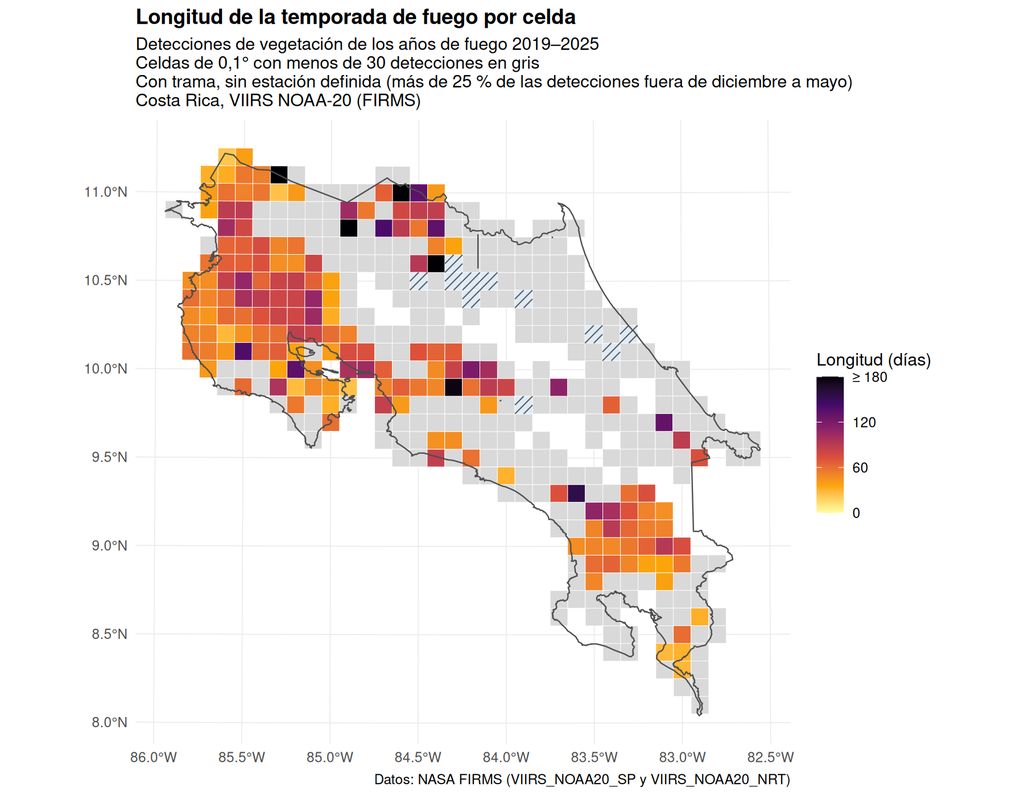

De las 523 celdas con alguna detección, 184 alcanzan el umbral y 11 quedan sin estación definida. En las 173 celdas con índices la temporada consolidada dura entre 23 y 196 días (mediana 60); el inicio de celda va del 2 de noviembre al 15 de abril y el fin del 22 de marzo al 24 de julio. `N50F` se calcula en 86 celdas, con valores entre 0,12 y 0,35 (mediana 0,20).

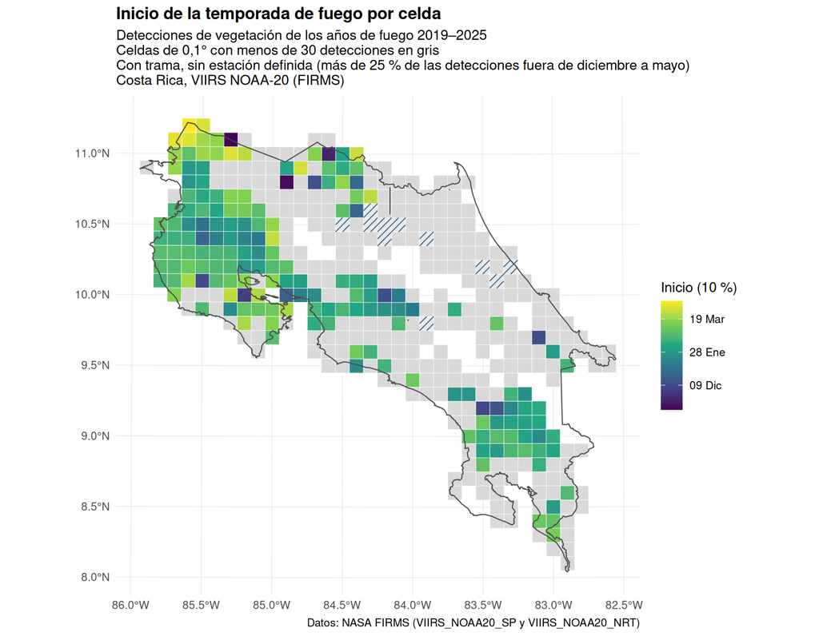

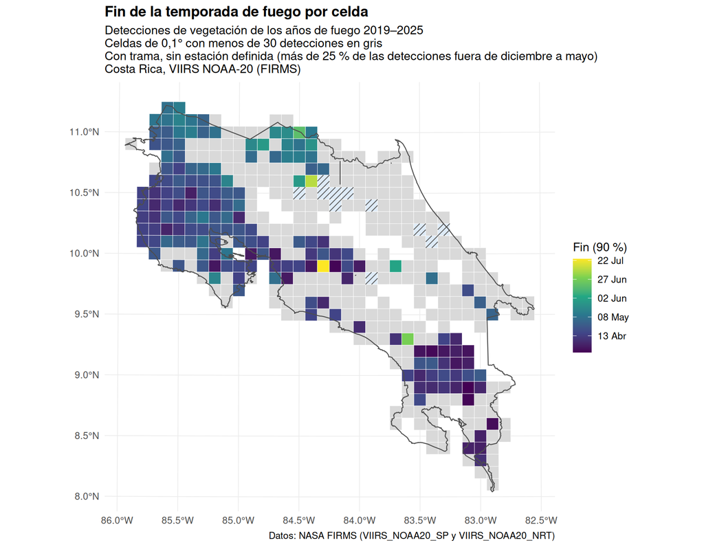

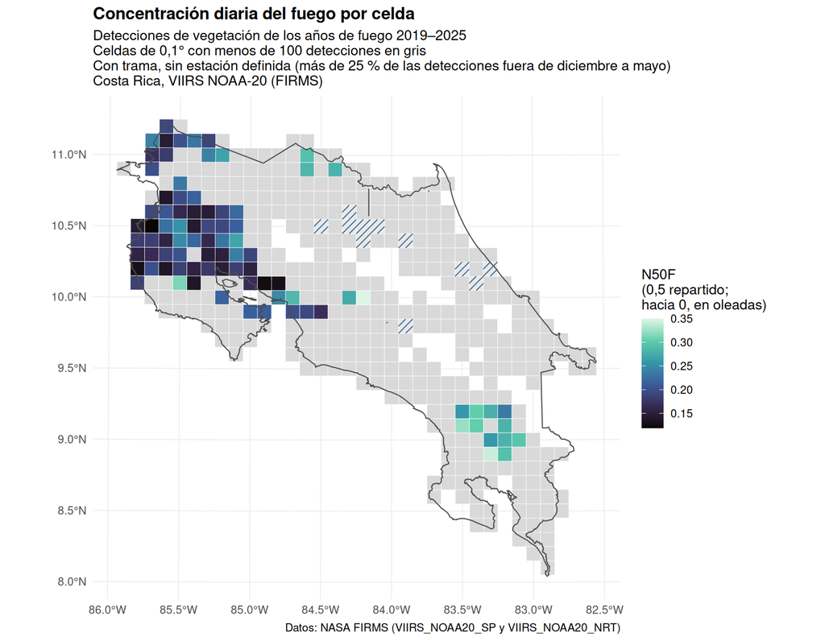

`FREC` (fracción de años con fuego), `DENS` (detecciones por km² de tierra y año) y `FRPI` (FRP mediana) se calculan sobre el **periodo base 2019–2025**, que con siete años deja a `FREC` en múltiplos de un séptimo. De las 523 celdas que tocan el país, 59 no tuvieron ninguna detección de vegetación en el periodo base; 231 arden tres de cada cuatro años o más. La densidad mediana entre las celdas con fuego es de 0,030 detecciones por km² y año, con un máximo de 1,59; la FRP mediana de las 184 celdas que alcanzan el umbral va de 1,0 a 7,7 MW. Ninguno de los tres se compara en nivel con MODIS. No hay mapa de ciclo diurno (`AQ`), porque ese control mide la mezcla de dos satélites en una misma serie.

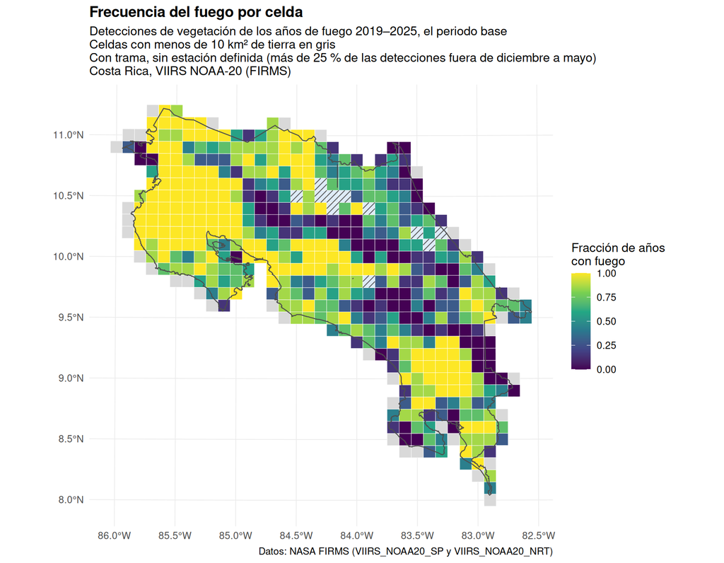

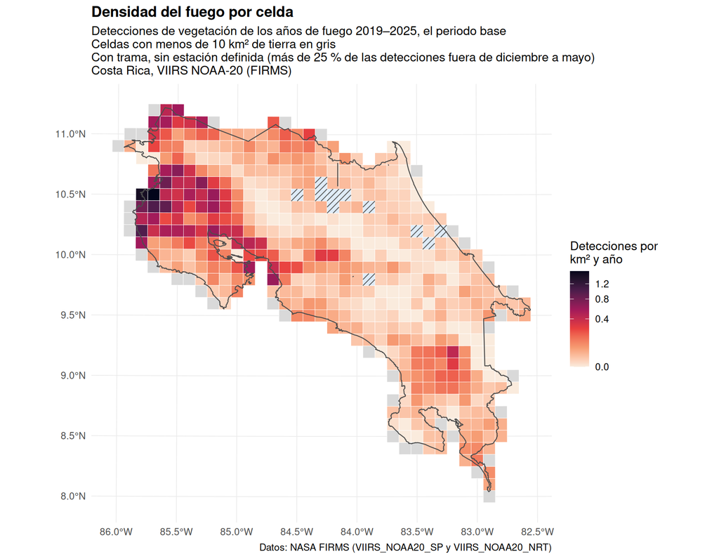

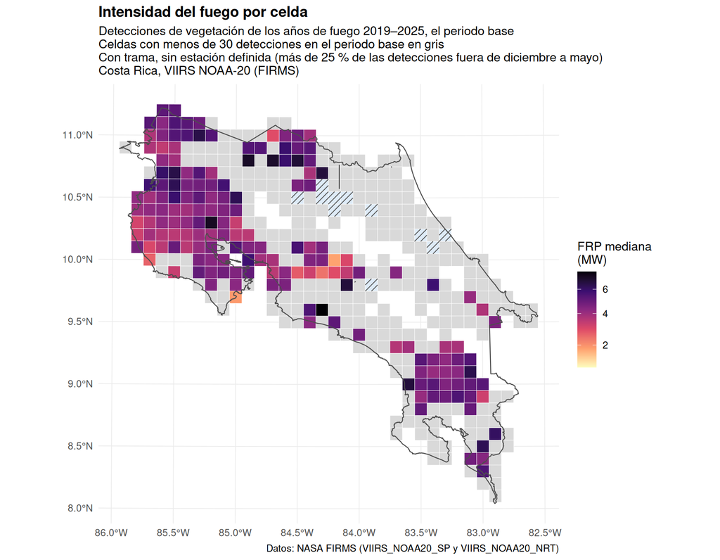

Los índices por celda están disponibles como CSV y como GeoTIFF con las mismas diez bandas con nombre que el de MODIS (la banda `aq`, vacía en VIIRS), acompañado de un estilo `.qml` de QGIS con la simbología de `LON`. Las mismas celdas pueden activarse como capa del mapa interactivo.

### Temporada por área de conservación

Los mapas por celda no tienen versión anual porque una celda reúne pocas detecciones en un año; el **área de conservación** (AC) del SINAC sí las reúne, y es la unidad con la que se gestiona el fuego. Cada detección de vegetación se asigna al AC que la contiene y los índices de la suite se calculan por AC y año de fuego con las mismas definiciones que la tabla nacional: `INI`, `FIN`, `LON`, `N50` y `C10` cuando el AC suma al menos 100 detecciones en el año (el 10 % de cien son diez detecciones; con menos la fecha saltaría con un día de quemas), la FRP mediana con 30, y los días extremos contra el percentil 95 de los propios días de fuego del AC en el periodo base. El periodo base de NOAA-20 tiene siete años, así que los umbrales P95 por AC y las anomalías se leen como provisionales hasta que el registro crezca.

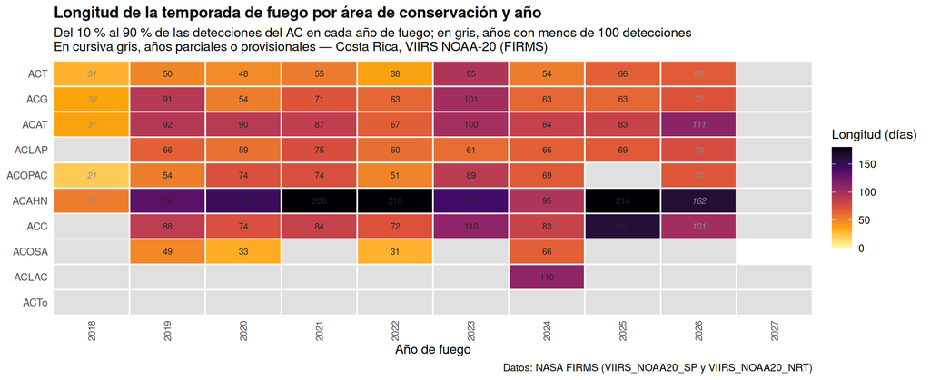

De los 70 pares AC-año completos, 53 (76 %) alcanzan el umbral y tienen temporada fechada. Nunca lo alcanzan ACTo: con esta plataforma no reúnen cien detecciones de vegetación en ningún año. La temporada más larga en promedio es la de **ACAHN** (165 días) y la más corta la de ACOSA (45). La lectura por filas dice si un año largo lo fue en todo el país o solo en una región; la lectura por columnas, qué AC arrastran la temporada nacional.

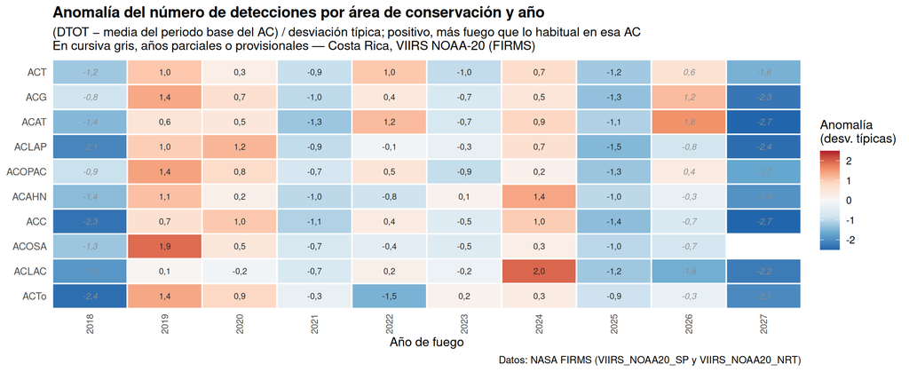

La anomalía estandarizada del número de detecciones (`Z_DTOT`, respecto de la media y la desviación típica de cada AC en el periodo base) es comparable entre AC porque es adimensional. El año con más AC por encima de una desviación típica fue **2019** (6 AC) y el año con más AC por debajo, 2025 (9).

| AC | Nombre | km² de tierra | Detecciones | Inicio (10 %) | Fin (90 %) | Longitud (días) | Fuera de dic–may (%) | N50F | Det./km²/año (base) | FRP mediana (MW) | Nota |
| --- | --- | --- | --- | --- | --- | --- | --- | --- | --- | --- | --- |
| ACT | Tempisque | 5149 | 10898 | 17 de febrero | 16 de abril | 59 | 1 | 0,09 | 0,302 | 3,9 |  |
| ACG | Guanacaste | 2936 | 5744 | 18 de febrero | 1 de mayo | 73 | 2 | 0,14 | 0,280 | 5,0 |  |
| ACAT | Arenal Tempisque | 3690 | 5603 | 31 de enero | 25 de abril | 85 | 1 | 0,14 | 0,217 | 4,6 |  |
| ACLAP | La Amistad Pacifico | 5558 | 2605 | 3 de febrero | 8 de abril | 65 | 2 | 0,19 | 0,067 | 4,6 |  |
| ACAHN | Huetar Norte | 8924 | 2378 | 15 de diciembre | 23 de mayo | 160 | 15 | 0,14 | 0,038 | 5,0 |  |
| ACOPAC | Pacifico Central | 2771 | 2280 | 8 de febrero | 16 de abril | 68 | 1 | 0,14 | 0,118 | 4,4 |  |
| ACC | Central | 8609 | 1809 | 22 de enero | 19 de abril | 88 | 4 | 0,19 | 0,030 | 3,7 |  |
| ACOSA | Osa | 4287 | 1050 | 13 de febrero | 5 de abril | 52 | 0 | 0,19 | 0,035 | 5,0 |  |
| ACLAC | La Amistad Caribe | 6068 | 557 | 6 de noviembre | 3 de mayo | 179 | 18 | 0,20 | 0,013 | 4,2 |  |
| ACTo | Tortuguero | 3049 | 140 | 22 de octubre | 31 de mayo | 222 | 24 | 0,27 | 0,007 | 4,6 |  |

El consolidado por AC se calcula con las mismas funciones y umbrales que el ráster por celda, tomando cada AC como una celda con su superficie terrestre. La temporada climatológica más larga es la de **ACTo** (222 días) y la más corta la de ACOSA (52); el inicio más temprano cae en ACTo (22 de octubre) y el más tardío en ACG (18 de febrero). Todas las AC tienen una estación definida. La densidad sobre el periodo base va de 0,302 detecciones por km² y año en ACT a 0,007 en ACTo: 46 veces de diferencia entre los extremos del país.

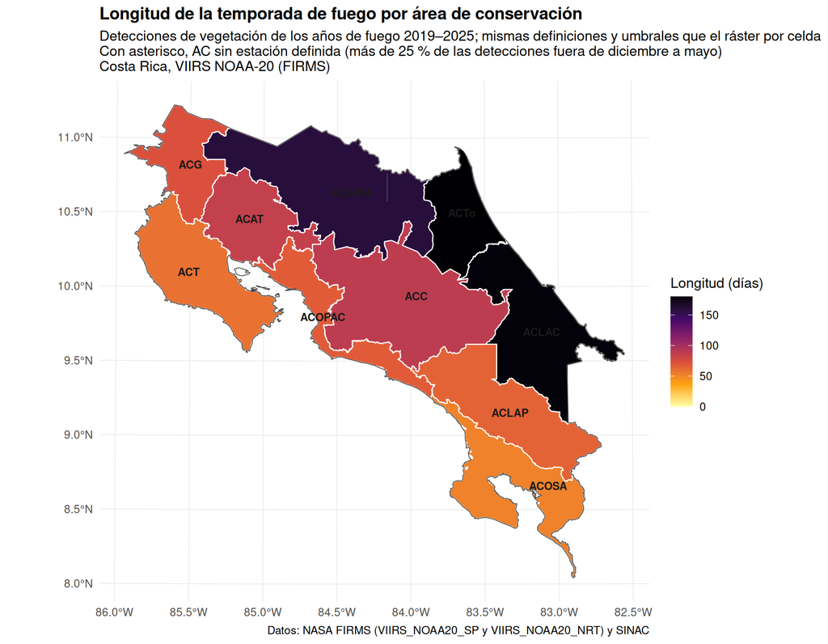

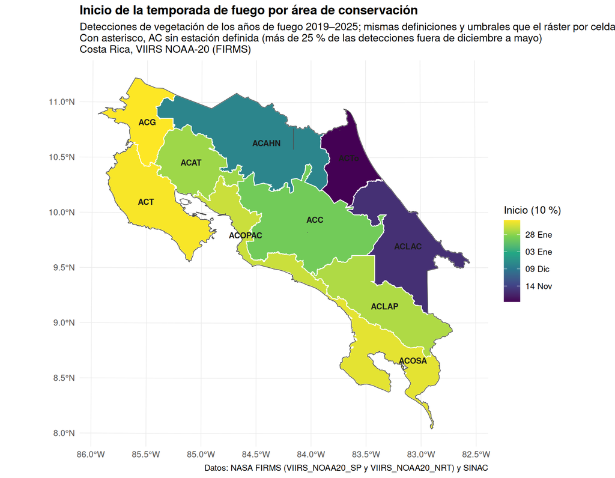

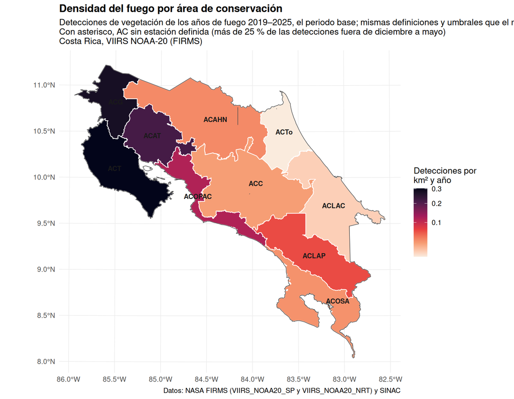

Las tablas están disponibles como CSV: índices anuales por AC y consolidado por AC. Los índices de un AC se comparan entre años y con otras AC de esta misma plataforma; entre plataformas, solo mediante el reporte de comparación.

### Fase ENSO

Es el primer factor externo con que se confrontan los índices anuales. El Niño reduce la lluvia de la vertiente del Pacífico de Centroamérica (Ropelewski y Halpert 1987) y en Costa Rica la variabilidad de la lluvia mensual está ligada al ENSO (Waylen, Caviedes y Quesada 1996); la pregunta es si los años Niño tienen temporadas más largas, más tempranas o con más fuego en el registro de esta plataforma. Se usa el **Índice Oceánico El Niño** (ONI) del CPC de la NOAA en el trimestre **diciembre–febrero** que cae dentro del año de fuego, justo antes de la temporada, ventana fijada antes de mirar los datos, y la fase del CPC (cinco trimestres consecutivos con |ONI| ≥ 0,5 °C). Los índices de conteo entran como anomalías sobre el periodo base para que la detectabilidad no intervenga. Con siete años completos, NOAA-20 apenas cubre un episodio de cada fase: la tabla se lee como descripción de esos años y nada más.

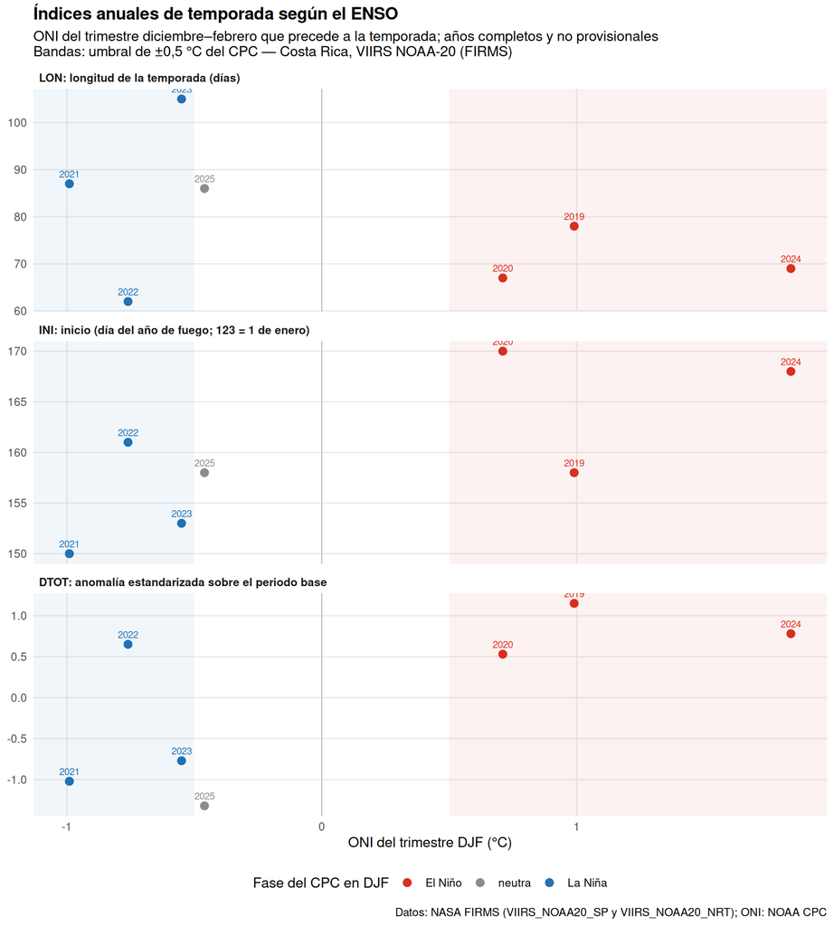

De los 7 años completos, 3 son de El Niño (2019, 2020, 2024), 3 de La Niña (2021, 2022, 2023) y 1 neutros; el ONI de DJF va de 1,8 °C en 2024 a -1,0 °C en 2021. La longitud mediana de la temporada es de 69 días en años Niño, 86 en neutros y 87 en Niña (ρ de Spearman con el ONI -0,29, p = 0,54); el inicio mediano cae el 15 de febrero, el 5 de febrero y el 31 de enero (ρ 0,61, p = 0,14), y la anomalía del número de detecciones es de 0,8, -1,3 y -0,8 desviaciones típicas (ρ 0,61, p = 0,15). La asociación más fuerte es con ND95 (ρ 0,70), y ningún índice alcanza p < 0,05. Con estas muestras el resultado es descriptivo: dice cómo se ordenan los años, no predice.

| Índice | El Niño: mediana (años) | Neutra: mediana (años) | La Niña: mediana (años) | ρ de Spearman con ONI_DJF | valor p |
| --- | --- | --- | --- | --- | --- |
| LON (días) | 69,0 (3) | 86,0 (1) | 87,0 (3) | -0,29 | 0,535 |
| INI (día) | 168,0 (3) | 158,0 (1) | 153,0 (3) | 0,61 | 0,144 |
| FIN (día) | 236,0 (3) | 243,0 (1) | 236,0 (3) | -0,04 | 0,937 |
| N50 (días) | 27,0 (3) | 27,0 (1) | 25,0 (3) | 0,11 | 0,812 |
| C10 (%) | 24,6 (3) | 26,0 (1) | 29,6 (3) | -0,14 | 0,760 |
| FRPI (MW) | 4,5 (3) | 4,8 (1) | 4,6 (3) | 0,18 | 0,699 |
| DTOT (anomalía) | 0,8 (3) | -1,3 (1) | -0,8 (3) | 0,61 | 0,148 |
| ND95 (anomalía) | 0,8 (3) | -1,1 (1) | -1,1 (3) | 0,70 | 0,077 |
| D95pTOT (anomalía) | 0,7 (3) | -1,1 (1) | -1,1 (3) | 0,37 | 0,413 |

Las tablas están disponibles como CSV: índices por año con ONI y fase y resumen por fase. La serie ONI es de la [NOAA CPC](https://www.cpc.ncep.noaa.gov/products/analysis_monitoring/ensostuff/ONI_v5.php).

### Detecciones excluidas por tipo de fuente

En el registro estándar de NOAA-20 hay **379** detecciones de volcanes, fuentes estáticas y mar, que las series mensuales y los mapas sí incluyen pero los índices de temporada apartan; la cola en tiempo casi real no trae el campo y cuenta como vegetación.

| Año de fuego | Vegetación | Sin tipo (NRT) | Volcán activo | Otra fuente estática | Mar | Excluidas |
| --- | --- | --- | --- | --- | --- | --- |
| 2018 | 1618 | 0 | 9 | 10 | 3 | 22 |
| 2019 | 7283 | 0 | 31 | 43 | 11 | 85 |
| 2020 | 5913 | 0 | 8 | 49 | 6 | 63 |
| 2021 | 2454 | 0 | 2 | 12 | 5 | 19 |
| 2022 | 6178 | 0 | 5 | 8 | 12 | 25 |
| 2023 | 3009 | 0 | 0 | 12 | 3 | 15 |
| 2024 | 6474 | 0 | 13 | 14 | 11 | 38 |
| 2025 | 1798 | 0 | 38 | 16 | 3 | 57 |
| 2026 | 5909 | 21 | 7 | 33 | 15 | 55 |
| 2027 | 0 | 95 | 0 | 0 | 0 | 0 |

Disponible también como CSV.

**Dónde están.** Las 310 detecciones de tipo 1 y 2 del registro se reparten en 5 celdas de 0,1°, pero 5 celdas con al menos 10 reúnen el 100 %. A cada celda fuente se le asigna una **firma** por reglas sobre sus propias detecciones (definidas en el [README](https://github.com/incendios-forestales/anomalias-termicas-costarica#mapa-de-fuentes-estáticas)): cráter volcánico si domina el tipo 1; fuente térmica nocturna persistente si al menos la mitad son nocturnas en tres o más años, porque lo que emite de noche está caliente por sí mismo; y reflejo urbano diurno, probable, si casi todas son diurnas, la firma del caso de Turrialba, puntos fijos sobre los techos del casco urbano que la máscara de la NASA catalogó como fuente estática. La localidad es la geocodificación inversa del centroide y dice dónde buscar la fuente, no cuál es.

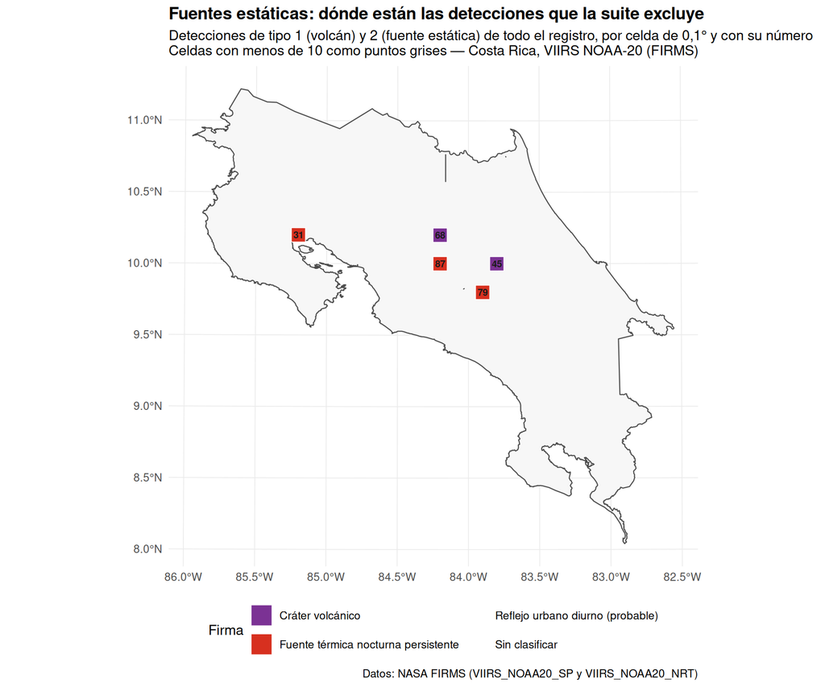

La mayor es La Ribera y La Uruca, entre Belén y San José (87 detecciones, fuente térmica nocturna persistente). Como en Suomi-NPP, el mapa es el de un sensor que ve de noche lo que está caliente y no los reflejos diurnos que dominan en MODIS. Cráteres: San Juan de Poás (cráter del Poás); Santa Cruz de Turrialba (cráter del Turrialba). Fuentes térmicas nocturnas persistentes: La Ribera y La Uruca, entre Belén y San José; Aguacaliente de Cartago y Llanos de Santa Lucía, Paraíso; Colorado de Abangares.

| Celda | Localidad de referencia | Firma | Volcán (tipo 1) | Fija (tipo 2) | % de la celda | Años (primero–último) | % diurnas | % de Terra | FRP mediana (MW) | Confianza mediana | Centroide (lat, lon) | Dispersión (m) |
| --- | --- | --- | --- | --- | --- | --- | --- | --- | --- | --- | --- | --- |
| c0995_m08425 | La Ribera y La Uruca, entre Belén y San José | Fuente térmica nocturna persistente | 0 | 87 | 25 | 6 (2018–2026) | 5 |  | 0,5 |  | 9,9686, -84,1558 | 307 |
| c0975_m08395 | Aguacaliente de Cartago y Llanos de Santa Lucía, Paraíso | Fuente térmica nocturna persistente | 0 | 79 | 53 | 9 (2018–2026) | 0 |  | 0,7 |  | 9,8316, -83,9049 | 150 |
| c1015_m08425 | San Juan de Poás (cráter del Poás) | Cráter volcánico | 68 | 0 | 91 | 6 (2019–2026) | 4 |  | 1,3 |  | 10,1980, -84,2316 | 213 |
| c0995_m08385 | Santa Cruz de Turrialba (cráter del Turrialba) | Cráter volcánico | 45 | 0 | 85 | 5 (2018–2022) | 7 |  | 1,2 |  | 10,0193, -83,7646 | 167 |
| c1015_m08525 | Colorado de Abangares | Fuente térmica nocturna persistente | 0 | 31 | 7 | 3 (2024–2026) | 3 |  | 0,8 |  | 10,2001, -85,1824 | 154 |

Todas las celdas con detecciones estáticas, con sus métricas, están en CSV.

## Detecciones por área de conservación

Cada detección se asigna al **área de conservación** del [SINAC](https://www.sinac.go.cr/) donde cae su punto; cada píxel de área quemada, a la del centroide del píxel. Las pocas detecciones que no caen en ninguna —desajustes de borde entre la capa del SINAC y el límite IGN 1:5000— se agrupan como *Sin asignar*.

[interactive chart not shown]

| Siglas | Área de conservación | Detecciones | % del total | Hectáreas quemadas |
| --- | --- | --- | --- | --- |
| ACT | Tempisque | 13419 | 32.6 | 98152 |
| ACG | Guanacaste | 7519 | 18.3 | 78079 |
| ACAT | Arenal Tempisque | 7291 | 17.7 | 62577 |
| ACLAP | La Amistad Pacifico | 2910 | 7.1 | 2822 |
| ACOPAC | Pacifico Central | 2847 | 6.9 | 9171 |
| ACAHN | Huetar Norte | 2823 | 6.9 | 2844 |
| ACC | Central | 2349 | 5.7 | 1432 |
| ACOSA | Osa | 1139 | 2.8 | 1411 |
| ACLAC | La Amistad Caribe | 594 | 1.4 | 385 |
| ACTo | Tortuguero | 173 | 0.4 | 257 |

[output cut: 1 more lines]

La distribución por año y área de conservación está disponible como CSV.

## Cobertura de la tierra

Cada detección corresponde a un píxel de 375 m en el nadir (mayor fuera de él), por lo que la cobertura se caracteriza sobre el *footprint* completo de la detección —una elipse con las dimensiones reales del píxel, columnas `scan` × `track`— y no sobre el punto exacto.

**Limitación**: WorldCover describe la cobertura de 2021, mientras que el registro abarca 2018–2026.

[interactive chart not shown]

El gráfico gemelo muestra las **hectáreas quemadas** según la clase dominante del píxel de VNP64A1 (Suomi-NPP).

[interactive chart not shown]

### Contraste con el Registro Nacional de Humedales

| Clase WorldCover | Detecciones | En humedal | % en humedal | Fracción del footprint en humedal | Hectáreas quemadas | % del área quemada en humedal |
| --- | --- | --- | --- | --- | --- | --- |
| Bosque | 29097 | 908 | 3.1 | 0.01 | 133813 | 1 |
| Pastizal | 9247 | 1083 | 11.7 | 0.072 | 58965 | 11.4 |
| Cultivos | 2001 | 148 | 7.4 | 0.032 | 64373 | 3 |
| Zonas construidas | 477 | 3 | 0.6 | 0 | 107 | 0 |
| Suelo desnudo / vegetación escasa | 115 | 60 | 52.2 | 0.178 | 0 |  |
| Cuerpos de agua | 85 | 37 | 43.5 | 0.245 | 299 | 50 |
| Manglar | 69 | 39 | 56.5 | 0.261 | 513 | 62.5 |
| Humedal herbáceo | 38 | 34 | 89.5 | 0.783 | 214 | 100 |
| Matorral | 2 | 0 | 0 | 0 | 0 |  |

De las **9 247** detecciones cuyo footprint domina el *pastizal* de WorldCover, el **11,7 %** cae dentro de un humedal registrado (con un **7 %** del footprint cubierto por humedal, en promedio). El polígono del registro que más detecciones concentra es *Sector Catalina 1*, con 284.

**Advertencia sobre la clase de humedal**: el registro asigna una sola clase por polígono; `clase_hum` describe el tipo de humedal *como sitio* y no la cobertura en cada punto de su extensión.

## El episodio del humedal Catalina, mayo de 2026

Casi todo lo que este reporte mide carece de contraparte en tierra. El episodio de mayo de 2026 en el humedal Catalina (Parque Nacional Palo Verde, cuenca baja del Tempisque) es la excepción: el 28 de mayo de 2026 la caída de un rayo encendió el interior del humedal, y una semana después Delfino.cr reportaba, con cifras del Minae-Sinac, que el fuego había afectado **cerca de 4 000 hectáreas** ([nota del 3 de junio de 2026](https://delfino.cr/2026/06/incendio-en-parque-nacional-palo-verde-afecto-cerca-de-4000-hectareas)). El combustible principal fue la *Typha*, una planta invasora que arde incluso sobre el agua. Hay entonces una fecha de ignición, una causa y una superficie oficial: tres cosas con las que auditar los productos satelitales.

**Lo que vio esta plataforma.** NOAA-20 registró **176 detecciones** en la ventana del evento, en 5 días, del 29 de mayo al 2 de junio de 2026 —el fuego apareció en las imágenes 1 día después de la ignición reportada—, con una potencia radiativa acumulada de 1 938 MW y un máximo de 68,1 MW en un solo píxel. 46 de esas detecciones son nocturnas: el fuego no se apagaba de noche. El día pico fue el 31 de mayo, con 65 detecciones.

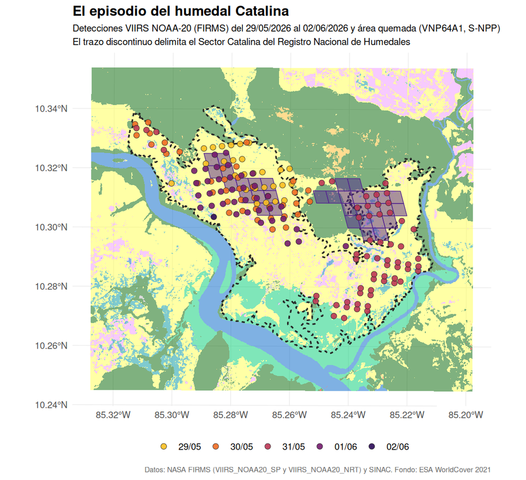

**Dónde ardió.** El **89,8 %** de las detecciones del episodio tiene como polígono dominante el *Sector Catalina* del Registro Nacional de Humedales, y el **92,0 %** cae en footprints donde WorldCover ve *pastizal*: un ejemplo concreto de que parte del “pastizal” que arde en Costa Rica es humedal estacional y no potrero.

**Lo que el área quemada no vio.** Para mayo y junio de 2026, VNP64A1, S-NPP marca **3228 hectáreas** quemadas en la zona del evento, frente a las 4 000 reportadas oficialmente: el producto satelital ve **1,2 veces menos superficie** que la contabilizada en tierra. La explicación está en cómo funciona el producto: declara quemado un píxel de 500 m ante un **cambio persistente de reflectancia**, y una quema de *Typha* sobre lámina de agua no lo produce. Las hectáreas de la tabla anual **sirven para comparar años entre sí, no para responder cuántas hectáreas se quemaron.** A la advertencia general de este reporte —que las hectáreas no provienen de NOAA-20 sino de Suomi-NPP— se suma entonces esta otra, que afecta por igual a las cuatro plataformas.

**Nivel de procesamiento**: las detecciones del episodio provienen del procesamiento en estándar. El tramo en tiempo casi real se refina cuando la NASA lo reprocesa, de modo que las cifras de los últimos días pueden cambiar retroactivamente.

## Fuentes de datos

- **NASA FIRMS** — Fire Information for Resource Management System, producto VIIRS_NOAA20_SP (VIIRS 375 m, NOAA-20/JPSS-1, procesamiento estándar). https://firms.modaps.eosdis.nasa.gov/. Cita sugerida: Schroeder, W., y Giglio, L. (2018). *VIIRS/JPSS1 Thermal Anomalies/Fire 6-Min L2 Swath 375m*, DOI: 10.5067/VIIRS/VJ114IMG.002.
- **NASA LP DAAC** — producto de área quemada VNP64A1 v002 (VIIRS/NPP, mensual, 500 m), **derivado de Suomi-NPP**: no existe equivalente de NOAA-20. Giglio, L., y Justice, C. (2021). *VNP64A1 VIIRS/NPP Burned Area Monthly L4 Global 500m SIN Grid V002*, DOI: 10.5067/VIIRS/VNP64A1.002.
- **IGN / SNIT** — cartografía oficial 1:5000: límite provincial (la unión de las siete provincias es el límite nacional del análisis). https://www.snitcr.go.cr/.
- **SINAC** — capas de áreas de conservación y Registro Nacional de Humedales (2016–2018), de su servicio WFS. https://geos1pne.sirefor.go.cr/wfs.
- **ESA WorldCover** — cobertura de la tierra 2021 a 10 m, v200. https://esa-worldcover.org/. Zanaga, D., et al. (2022). *ESA WorldCover 10 m 2021 v200*, DOI: 10.5281/zenodo.7254221.

Los reportes análogos: MODIS (desde 2001), VIIRS en Suomi-NPP (desde 2012) y VIIRS en NOAA-21 (desde 2024).

El código de este análisis está disponible en https://github.com/incendios-forestales/anomalias-termicas-costarica.